# Direct Labor % Predictions

## Labor and Revenue Analysis – Sales Orders

#### Overview

This notebook analyzes moving services data to provide insights on labor efficiency and revenue. It calculates Direct Labor % per sales order, aggregates revenue, and allows scenario testing based on mover and driver pay rates.

#### Purpose

The goal is to understand how labor costs impact profitability and identify opportunities to optimize staffing and pay. Key questions addressed:

- How does DL% vary across service types and months?
- How do changes in pay rates affect predicted labor efficiency?
- What are realistic labor cost and revenue expectations per month?

#### Data

We integrate three datasets:

- Service Revenue – all services, fees, discounts, and adjustments.
- Pay Data – hours worked by movers and drivers, including commission-based jobs.
- Rate Data – employee pay rates over time.

#### Workflow

- Clean and merge data to ensure accurate totals and metrics.
- Calculate labor hours, labor costs, total revenue, and DL%.
- Calculate predictions for DL% and run pay-rate scenario analysis.
- Output monthly predictions to inform operational decisions.

```python
import pandas as pd
import matplotlib.pyplot as plt
import seaborn as sns
import numpy as np
%matplotlib inline
import warnings

warnings.filterwarnings("ignore", category=FutureWarning)
```

```python
rev_df = pd.read_excel("Sales Order Revenue.xlsx")
rev_df.head()
```

|  | Date | Sales Order Number | Services | Special Fees | Service Discount | Travel Charges | Fuel Surcharge | Sales Items | Sales Item Discount | Valuation | Adjustments | Flat Fee Discount | Cancellation Fee |
| --- | --- | --- | --- | --- | --- | --- | --- | --- | --- | --- | --- | --- | --- |
| 0 | 2024-01-04 | 0336-68358 | 0.0 | 0 | 0.0 | 0.0 | 0 | -1400.0 | 0.0 | 0 | 0.0 | 0.0 | 0 |
| 1 | 2024-01-05 | 0336-69462 | 0.0 | 0 | 0.0 | 0.0 | 0 | 375.0 | 0.0 | 0 | 0.0 | 0.0 | 0 |
| 2 | 2024-02-08 | 0336-69822 | 0.0 | 0 | 0.0 | 0.0 | 0 | 375.0 | 0.0 | 0 | 0.0 | 0.0 | 0 |
| 3 | 2024-03-04 | 0336-70097 | 0.0 | 0 | 0.0 | 0.0 | 0 | 375.0 | 0.0 | 0 | 0.0 | 0.0 | 0 |
| 4 | 2024-04-08 | 0336-70552 | 0.0 | 0 | 0.0 | 0.0 | 0 | 375.0 | 0.0 | 0 | 0.0 | 0.0 | 0 |

```python
rev_df['Day of Week'] = rev_df['Date'].dt.day_name()
rev_df[['Date','Day of Week']].head()
```

|  | Date | Day of Week |
| --- | --- | --- |
| 0 | 2024-01-04 | Thursday |
| 1 | 2024-01-05 | Friday |
| 2 | 2024-02-08 | Thursday |
| 3 | 2024-03-04 | Monday |
| 4 | 2024-04-08 | Monday |

```python
service_cols = [
    'Services', 'Special Fees', 'Service Discount', 'Travel Charges',
    'Fuel Surcharge', 'Sales Items', 'Sales Item Discount',
    'Valuation', 'Adjustments', 'Flat Fee Discount', 'Cancellation Fee'
]

rev_long_df = pd.melt(
    rev_df,
    id_vars=['Date', 'Sales Order Number'],
    value_vars=service_cols,
    var_name='Service Type',
    value_name='Service Revenue'
)

rev_long_df['Service Revenue'] = pd.to_numeric(rev_long_df['Service Revenue'], errors='coerce').fillna(0)
```

```python
rev_long_df = rev_long_df.dropna(subset=['Service Revenue'])
rev_long_df.shape
```

```
(33792, 4)
```

```python
rev_long_df.info()
```

```
<class 'pandas.core.frame.DataFrame'>
RangeIndex: 33792 entries, 0 to 33791
Data columns (total 4 columns):
 #   Column              Non-Null Count  Dtype
---  ------              --------------  -----
 0   Date                33209 non-null  datetime64[ns]
 1   Sales Order Number  33792 non-null  object
 2   Service Type        33792 non-null  object
 3   Service Revenue     33792 non-null  float64
dtypes: datetime64[ns](1), float64(1), object(2)
memory usage: 1.0+ MB
```

```python
rev_long_df = rev_long_df.dropna(subset=['Date'])
rev_long_df.info()
```

```
<class 'pandas.core.frame.DataFrame'>
Index: 33209 entries, 0 to 33785
Data columns (total 4 columns):
 #   Column              Non-Null Count  Dtype
---  ------              --------------  -----
 0   Date                33209 non-null  datetime64[ns]
 1   Sales Order Number  33209 non-null  object
 2   Service Type        33209 non-null  object
 3   Service Revenue     33209 non-null  float64
dtypes: datetime64[ns](1), float64(1), object(2)
memory usage: 1.3+ MB
```

```python
rev_long_df.sample(5)
```

|  | Date | Sales Order Number | Service Type | Service Revenue |
| --- | --- | --- | --- | --- |
| 8884 | 2024-04-09 | 0580-70598 | Service Discount | 0.0 |
| 122 | 2024-07-25 | 0336-72001 | Services | 185.0 |
| 12843 | 2024-01-24 | 0336-69625 | Fuel Surcharge | 0.0 |
| 6124 | 2024-12-27 | 0580-73559 | Special Fees | 0.0 |
| 26589 | 2024-01-21 | 0336-69328 | Adjustments | 0.0 |

```python
rev_long_df.loc[rev_long_df['Sales Order Number'] == '0336-70787']
```

|  | Date | Sales Order Number | Service Type | Service Revenue |
| --- | --- | --- | --- | --- |
| 932 | 2024-04-24 | 0336-70787 | Services | 2252.5 |
| 4004 | 2024-04-24 | 0336-70787 | Special Fees | 0.0 |
| 7076 | 2024-04-24 | 0336-70787 | Service Discount | 0.0 |
| 10148 | 2024-04-24 | 0336-70787 | Travel Charges | 307.0 |
| 13220 | 2024-04-24 | 0336-70787 | Fuel Surcharge | 0.0 |
| 16292 | 2024-04-24 | 0336-70787 | Sales Items | 0.0 |
| 19364 | 2024-04-24 | 0336-70787 | Sales Item Discount | 0.0 |
| 22436 | 2024-04-24 | 0336-70787 | Valuation | 60.0 |
| 25508 | 2024-04-24 | 0336-70787 | Adjustments | 0.0 |
| 28580 | 2024-04-24 | 0336-70787 | Flat Fee Discount | 0.0 |
| 31652 | 2024-04-24 | 0336-70787 | Cancellation Fee | 0.0 |

- imported revenue spreadsheet
- added a day of the week column
- dropped null rows
- converted to long format
- checked that the rows for SOs are summing correctly for Total Revenue

```python
pay_df = pd.read_excel("2024 Payroll Detail.xlsx")

#redact employee names
pay_df['Employee Name'] = (
    pay_df['Employee Name']
    .rank(method='dense')
    .astype(int)
    .map(lambda x: f'Employee {x}')
)


pay_df.head()
```

|  | Employee Name | Activity Type | Sales Order Number | Date | Actual Hours | Commission |
| --- | --- | --- | --- | --- | --- | --- |
| 0 | Employee 1 | EPR – General | NaN | 2024-07-21 | 0.25 | 0.0 |
| 1 | Employee 1 | EPR – General | NaN | 2024-07-28 | 0.50 | 0.0 |
| 2 | Employee 1 | EPR – General | NaN | 2024-08-04 | 0.75 | 0.0 |
| 3 | Employee 1 | EPR – General | NaN | 2024-08-11 | 0.75 | 0.0 |
| 4 | Employee 1 | EPR – General | NaN | 2024-08-16 | 1.75 | 0.0 |

```python
pay_df['Activity Type'].value_counts()
```

```
Activity Type
Moving                          4086
Driving                         3208
EPR – General                   2224
Training                         828
Seller                           799
Mover Exempt                     486
Driver Exempt                    442
Uniform/Equipment Deduction      313
Emp Total:                       240
EPR – Clerical/support staff     217
Manager                          161
Claim Adjustment                 157
EPR – Storage                    132
Light Duty                        40
Shared Labor                       4
Marketing                          3
Name: count, dtype: int64
```

```python
direct_labor_activities = ['Moving', 'Driving', 'Mover Exempt', 'Driver Exempt']
```

```python
pay_df = pay_df[pay_df['Activity Type'].str.contains('|'.join(direct_labor_activities), na=False)]
```

```python
pay_df['Activity Type'].unique()
```

```
array(['Moving', 'Driver Exempt', 'Driving', 'Mover Exempt'], dtype=object)
```

```python
pay_df['Sales Order Number'].isna().sum()
```

```
79
```

```python
pay_df.info()
```

```
<class 'pandas.core.frame.DataFrame'>
Index: 8222 entries, 9 to 13315
Data columns (total 6 columns):
 #   Column              Non-Null Count  Dtype
---  ------              --------------  -----
 0   Employee Name       8222 non-null   object
 1   Activity Type       8222 non-null   object
 2   Sales Order Number  8143 non-null   object
 3   Date                7887 non-null   datetime64[ns]
 4   Actual Hours        8222 non-null   float64
 5   Commission          8222 non-null   float64
dtypes: datetime64[ns](1), float64(2), object(3)
memory usage: 449.6+ KB
```

```python
pay_df[pay_df['Sales Order Number'].isnull()]
```

|  | Employee Name | Activity Type | Sales Order Number | Date | Actual Hours | Commission |
| --- | --- | --- | --- | --- | --- | --- |
| 450 | Employee 5 | Moving | NaN | 2024-02-02 | 5.00 | 0.0 |
| 459 | Employee 5 | Moving | NaN | 2024-02-11 | 0.00 | 0.0 |
| 673 | Employee 12 | Moving | NaN | 2024-04-26 | 11.75 | 0.0 |
| 675 | Employee 12 | Moving | NaN | 2024-04-29 | 10.00 | 0.0 |
| 676 | Employee 12 | Moving | NaN | 2024-05-03 | 9.50 | 0.0 |
| ... | ... | ... | ... | ... | ... | ... |
| 12453 | Employee 222 | Driving | NaN | 2024-01-14 | 0.00 | 0.0 |
| 12493 | Employee 222 | Driving | NaN | 2024-04-26 | 11.75 | 0.0 |
| 12504 | Employee 222 | Driving | NaN | 2024-05-12 | 0.00 | 0.0 |
| 12717 | Employee 224 | Moving | NaN | 2024-12-13 | 0.75 | 0.0 |
| 12961 | Employee 226 | Moving | NaN | 2024-12-30 | 0.50 | 0.0 |

79 rows × 6 columns

```python
pay_df.sample(5)
```

|  | Employee Name | Activity Type | Sales Order Number | Date | Actual Hours | Commission |
| --- | --- | --- | --- | --- | --- | --- |
| 1084 | Employee 16 | Driving | 0580-72992 | 2024-10-25 | 6.25 | 0.0 |
| 7172 | Employee 119 | Moving | 0580-71634 | 2024-07-01 | 9.25 | 0.0 |
| 6387 | Employee 107 | Moving | 0580-69397 | 2024-01-08 | 9.00 | 0.0 |
| 835 | Employee 14 | Driving | 0336-69675 | 2024-02-16 | 3.50 | 0.0 |
| 7400 | Employee 128 | Driving | 0336-71029 | 2024-05-28 | 9.25 | 0.0 |

```python
pay_df.dropna(subset=['Sales Order Number'], inplace=True)
pay_df['Sales Order Number'].isna().sum()
```

```
0
```

```python
pay_df.rename(columns={'Employee Name': 'Name'}, inplace=True)
```

```python
# Hourly activities
hourly_df = pay_df[pay_df['Activity Type'].isin(['Moving', 'Driving'])].copy()

# Commission activities
commission_df = pay_df[pay_df['Activity Type'].isin(['Mover Exempt', 'Driver Exempt'])].copy()
```

```python
# Sum actual hours for movers and drivers for hourly jobs
mover_hours = hourly_df[hourly_df['Activity Type'] == 'Moving'].groupby('Sales Order Number')['Actual Hours'].sum().rename('Mover Hours')
driver_hours = hourly_df[hourly_df['Activity Type'] == 'Driving'].groupby('Sales Order Number')['Actual Hours'].sum().rename('Driver Hours')

# Combine into one dataframe
hours_df = pd.concat([mover_hours, driver_hours], axis=1).fillna(0)
```

```python
commission_df['Commission Hours'] = commission_df['Actual Hours']  # will be 0 or 0.25
commission_hours = commission_df.groupby('Sales Order Number')['Commission Hours'].sum()
```

```python
hours_df
```

| Sales Order Number | Mover Hours | Driver Hours |
| --- | --- | --- |
| 0336-68733 | 10.00 | 5.00 |
| 0336-68734 | 9.25 | 18.50 |
| 0336-68790 | 19.00 | 9.50 |
| 0336-69024 | 15.50 | 7.75 |
| 0336-69167 | 2.75 | 2.75 |
| ... | ... | ... |
| 0580-72378 | 0.00 | 7.00 |
| 0580-72433 | 0.00 | 14.00 |
| 0580-72593 | 0.00 | 9.50 |
| 0580-73205 | 0.00 | 10.00 |
| 0580-73541 | 0.00 | 3.75 |

2467 rows × 2 columns

- imported payroll spreadsheet
- removed all payroll activities not related to direct labor
- dropped rows with null sales order values
- created a dataframe to hold mover and driver hours separately
- created dataframes to separate commission pay and hourly jobs

```python
rate_df = pd.read_excel("ML Direct Labor Pay Rates.xlsx")

#redact employee names
name_map = {
    name: f'Employee {i+1}'
    for i, name in enumerate(rate_df['Name'].dropna().unique())
}

rate_df['Name'] = rate_df['Name'].map(name_map)

rate_df.head()
```

|  | Home Department Code | Name | Home Department Description | Regular Pay Rate Amount | Pay Date |
| --- | --- | --- | --- | --- | --- |
| 0 | 033610 | Employee 1 | Mover | 17.0 | 2024-09-24 |
| 1 | 033610 | Employee 2 | Mover | 18.0 | 2024-05-28 |
| 2 | 033610 | Employee 2 | Mover | 18.0 | 2024-06-04 |
| 3 | 033610 | Employee 2 | Mover | 18.0 | 2024-06-11 |
| 4 | 033610 | Employee 2 | Mover | 18.0 | 2024-06-18 |

```python
rate_df.shape
```

```
(2129, 5)
```

```python
rate_df.info()
```

```
<class 'pandas.core.frame.DataFrame'>
RangeIndex: 2129 entries, 0 to 2128
Data columns (total 5 columns):
 #   Column                       Non-Null Count  Dtype
---  ------                       --------------  -----
 0   Home Department Code         2129 non-null   object
 1   Name                         2127 non-null   object
 2   Home Department Description  2127 non-null   object
 3   Regular Pay Rate Amount      2128 non-null   float64
 4   Pay Date                     2127 non-null   datetime64[ns]
dtypes: datetime64[ns](1), float64(1), object(3)
memory usage: 83.3+ KB
```

```python
# null values are grand total rows
rate_df.dropna(subset=['Name'], inplace=True)
rate_df.info()
```

```
<class 'pandas.core.frame.DataFrame'>
Index: 2127 entries, 0 to 2126
Data columns (total 5 columns):
 #   Column                       Non-Null Count  Dtype
---  ------                       --------------  -----
 0   Home Department Code         2127 non-null   object
 1   Name                         2127 non-null   object
 2   Home Department Description  2127 non-null   object
 3   Regular Pay Rate Amount      2127 non-null   float64
 4   Pay Date                     2127 non-null   datetime64[ns]
dtypes: datetime64[ns](1), float64(1), object(3)
memory usage: 99.7+ KB
```

- imported pay rate spreadsheet
- dropped rows where name was null, as those rows were grand total rows

```python
final_df = rev_long_df.merge(hours_df, on='Sales Order Number', how='left')
final_df.sample(5)
```

|  | Date | Sales Order Number | Service Type | Service Revenue | Mover Hours | Driver Hours |
| --- | --- | --- | --- | --- | --- | --- |
| 29000 | 2024-12-03 | 0336-73385 | Flat Fee Discount | 0.0 | 2.0 | 2.0 |
| 1173 | 2024-07-05 | 0336-71738 | Services | 0.0 | NaN | NaN |
| 6422 | 2024-11-04 | 0336-73134 | Service Discount | 0.0 | NaN | NaN |
| 11267 | 2024-06-28 | 0336-71602 | Travel Charges | 443.0 | 22.5 | 7.5 |
| 16358 | 2024-06-27 | 0336-71478 | Sales Items | 0.0 | 11.0 | 5.5 |

```python
# Drop Commission Pay column as it’s not needed
pay_df = pay_df.drop(columns=['Commission Pay'], errors='ignore')
pay_df.sample()
```

|  | Name | Activity Type | Sales Order Number | Date | Actual Hours | Commission |
| --- | --- | --- | --- | --- | --- | --- |
| 6422 | Employee 108 | Driving | 0580-72593 | 2024-10-12 | 4.75 | 0.0 |

```python
# Keep only the latest pay rate per employee
latest_rate_df = rate_df.sort_values('Pay Date').drop_duplicates('Name', keep='last')

pay_df = pay_df.merge(latest_rate_df[['Name', 'Regular Pay Rate Amount']], on='Name', how='left')
pay_df.sample()
```

|  | Name | Activity Type | Sales Order Number | Date | Actual Hours | Commission | Regular Pay Rate Amount |
| --- | --- | --- | --- | --- | --- | --- | --- |
| 7986 | Employee 226 | Driving | 0580-71667 | 2024-07-02 | 3.25 | 0.0 | 20.0 |

```python
pay_df['Labor Cost'] = (pay_df['Actual Hours'] * pay_df['Regular Pay Rate Amount']) + pay_df['Commission']
pay_df.sample()
```

|  | Name | Activity Type | Sales Order Number | Date | Actual Hours | Commission | Regular Pay Rate Amount | Labor Cost |
| --- | --- | --- | --- | --- | --- | --- | --- | --- |
| 5997 | Employee 174 | Mover Exempt | 0336-71316 | 2024-06-07 | 0.5 | 191.44 | 17.0 | 199.94 |

```python
labor_summary = pay_df.groupby('Sales Order Number', as_index=False)['Labor Cost'].sum()
final_df = final_df.merge(labor_summary, on='Sales Order Number', how='left')
final_df.sample(5)
```

|  | Date | Sales Order Number | Service Type | Service Revenue | Mover Hours | Driver Hours | Labor Cost |
| --- | --- | --- | --- | --- | --- | --- | --- |
| 28568 | 2024-07-31 | 0336-71967 | Flat Fee Discount | 0.0 | 13.00 | 6.50 | 351.00 |
| 29571 | 2024-12-13 | 0336-73359 | Flat Fee Discount | 0.0 | 7.25 | 10.00 | 329.50 |
| 9516 | 2024-09-05 | 0336-72510 | Travel Charges | 0.0 | NaN | NaN | NaN |
| 10124 | 2024-05-20 | 0336-70907 | Travel Charges | 382.0 | 21.00 | 7.00 | 532.00 |
| 24043 | 2024-10-25 | 0580-72992 | Valuation | 100.0 | 6.25 | 6.25 | 243.75 |

```python
total_revenue_per_order = rev_long_df.groupby('Sales Order Number', as_index=False)['Service Revenue'].sum()
total_revenue_per_order = total_revenue_per_order.rename(columns={'Service Revenue': 'Total Revenue'})
```

```python
final_df = final_df.merge(total_revenue_per_order, on='Sales Order Number', how='left')
final_df.sample()
```

|  | Date | Sales Order Number | Service Type | Service Revenue | Mover Hours | Driver Hours | Labor Cost | Total Revenue |
| --- | --- | --- | --- | --- | --- | --- | --- | --- |
| 854 | 2024-04-08 | 0336-70502 | Services | 1776.25 | 17.5 | 8.75 | 490.0 | 2142.25 |

```python
commission_per_order = pay_df.groupby('Sales Order Number', as_index=False)['Commission'].sum()
final_df = final_df.merge(commission_per_order, on='Sales Order Number', how='left')
final_df.sample()
```

|  | Date | Sales Order Number | Service Type | Service Revenue | Mover Hours | Driver Hours | Labor Cost | Total Revenue | Commission |
| --- | --- | --- | --- | --- | --- | --- | --- | --- | --- |
| 8917 | 2024-10-04 | 0580-72536 | Service Discount | 0.0 | 4.25 | 4.25 | 144.5 | 799.75 | 0.0 |

```python
final_df.loc[final_df['Sales Order Number'] == '0336-72666']
```

|  | Date | Sales Order Number | Service Type | Service Revenue | Mover Hours | Driver Hours | Labor Cost | Total Revenue | Commission |
| --- | --- | --- | --- | --- | --- | --- | --- | --- | --- |
| 1649 | 2024-10-04 | 0336-72666 | Services | 612.5 | 8.0 | 4.0 | 224.0 | 672.5 | 0.0 |
| 4668 | 2024-10-04 | 0336-72666 | Special Fees | 0.0 | 8.0 | 4.0 | 224.0 | 672.5 | 0.0 |
| 7687 | 2024-10-04 | 0336-72666 | Service Discount | 0.0 | 8.0 | 4.0 | 224.0 | 672.5 | 0.0 |
| 10706 | 2024-10-04 | 0336-72666 | Travel Charges | 0.0 | 8.0 | 4.0 | 224.0 | 672.5 | 0.0 |
| 13725 | 2024-10-04 | 0336-72666 | Fuel Surcharge | 0.0 | 8.0 | 4.0 | 224.0 | 672.5 | 0.0 |
| 16744 | 2024-10-04 | 0336-72666 | Sales Items | 0.0 | 8.0 | 4.0 | 224.0 | 672.5 | 0.0 |
| 19763 | 2024-10-04 | 0336-72666 | Sales Item Discount | 0.0 | 8.0 | 4.0 | 224.0 | 672.5 | 0.0 |
| 22782 | 2024-10-04 | 0336-72666 | Valuation | 60.0 | 8.0 | 4.0 | 224.0 | 672.5 | 0.0 |
| 25801 | 2024-10-04 | 0336-72666 | Adjustments | 0.0 | 8.0 | 4.0 | 224.0 | 672.5 | 0.0 |
| 28820 | 2024-10-04 | 0336-72666 | Flat Fee Discount | 0.0 | 8.0 | 4.0 | 224.0 | 672.5 | 0.0 |
| 31839 | 2024-10-04 | 0336-72666 | Cancellation Fee | 0.0 | 8.0 | 4.0 | 224.0 | 672.5 | 0.0 |

```python
final_df = final_df.dropna(subset=['Mover Hours', 'Driver Hours'])
final_df.info()
```

```
<class 'pandas.core.frame.DataFrame'>
Index: 27797 entries, 9 to 33208
Data columns (total 9 columns):
 #   Column              Non-Null Count  Dtype
---  ------              --------------  -----
 0   Date                27797 non-null  datetime64[ns]
 1   Sales Order Number  27797 non-null  object
 2   Service Type        27797 non-null  object
 3   Service Revenue     27797 non-null  float64
 4   Mover Hours         27797 non-null  float64
 5   Driver Hours        27797 non-null  float64
 6   Labor Cost          27797 non-null  float64
 7   Total Revenue       27797 non-null  float64
 8   Commission          27797 non-null  float64
dtypes: datetime64[ns](1), float64(6), object(2)
memory usage: 2.1+ MB
```

```python
dl_percentage = final_df.groupby('Sales Order Number').apply(
    lambda x: (x['Labor Cost'].iloc[0] - x['Commission'].iloc[0]) / x['Total Revenue'].iloc[0] * 100
).reset_index(name='Direct Labor %')

final_df = final_df.drop(columns=['Direct Labor %'], errors='ignore')  # drop old column
final_df = final_df.merge(dl_percentage, on='Sales Order Number', how='left')
final_df.sample(5)
```

|  | Date | Sales Order Number | Service Type | Service Revenue | Mover Hours | Driver Hours | Labor Cost | Total Revenue | Commission | Direct Labor % |
| --- | --- | --- | --- | --- | --- | --- | --- | --- | --- | --- |
| 23792 | 2024-08-02 | 0336-72098 | Flat Fee Discount | 0.00 | 1.50 | 1.50 | 64.5 | 623.75 | 0.0 | 10.340681 |
| 26682 | 2024-11-18 | 0336-73235 | Cancellation Fee | 0.00 | 17.00 | 8.50 | 484.5 | 2039.00 | 0.0 | 23.761648 |
| 9338 | 2024-05-30 | 0336-71205 | Travel Charges | 356.25 | 13.00 | 6.50 | 364.0 | 1983.75 | 0.0 | 18.349086 |
| 22295 | 2024-01-05 | 0580-69433 | Adjustments | 0.00 | 6.25 | 6.25 | 212.5 | 1132.50 | 0.0 | 18.763797 |
| 21071 | 2024-06-18 | 0336-71442 | Adjustments | 0.00 | 4.50 | 4.50 | 153.0 | 962.50 | 0.0 | 15.896104 |

```python
final_df.loc[final_df['Sales Order Number'] == '0336-72120']
```

|  | Date | Sales Order Number | Service Type | Service Revenue | Mover Hours | Driver Hours | Labor Cost | Total Revenue | Commission | Direct Labor % |
| --- | --- | --- | --- | --- | --- | --- | --- | --- | --- | --- |
| 1886 | 2024-08-19 | 0336-72120 | Services | 323.75 | 8.0 | 4.0 | 204.0 | 615.0 | 0.0 | 33.170732 |
| 4413 | 2024-08-19 | 0336-72120 | Special Fees | 0.00 | 8.0 | 4.0 | 204.0 | 615.0 | 0.0 | 33.170732 |
| 6940 | 2024-08-19 | 0336-72120 | Service Discount | 0.00 | 8.0 | 4.0 | 204.0 | 615.0 | 0.0 | 33.170732 |
| 9467 | 2024-08-19 | 0336-72120 | Travel Charges | 231.25 | 8.0 | 4.0 | 204.0 | 615.0 | 0.0 | 33.170732 |
| 11994 | 2024-08-19 | 0336-72120 | Fuel Surcharge | 0.00 | 8.0 | 4.0 | 204.0 | 615.0 | 0.0 | 33.170732 |
| 14521 | 2024-08-19 | 0336-72120 | Sales Items | 0.00 | 8.0 | 4.0 | 204.0 | 615.0 | 0.0 | 33.170732 |
| 17048 | 2024-08-19 | 0336-72120 | Sales Item Discount | 0.00 | 8.0 | 4.0 | 204.0 | 615.0 | 0.0 | 33.170732 |
| 19575 | 2024-08-19 | 0336-72120 | Valuation | 60.00 | 8.0 | 4.0 | 204.0 | 615.0 | 0.0 | 33.170732 |
| 22102 | 2024-08-19 | 0336-72120 | Adjustments | 0.00 | 8.0 | 4.0 | 204.0 | 615.0 | 0.0 | 33.170732 |
| 24629 | 2024-08-19 | 0336-72120 | Flat Fee Discount | 0.00 | 8.0 | 4.0 | 204.0 | 615.0 | 0.0 | 33.170732 |
| 27156 | 2024-08-19 | 0336-72120 | Cancellation Fee | 0.00 | 8.0 | 4.0 | 204.0 | 615.0 | 0.0 | 33.170732 |

- merged revenue and hours dataframes
- created a column in pay_df to get the latest pay rate
- calculated the labor cost by multiplying actual hours * pay rate + commission
- calculated the DL %
- checked randomized sales orders for accuracy

```python
final_df['Day of Week'] = final_df['Date'].dt.day_name()
```

```python
final_df_clean = final_df[final_df['Direct Labor %'] != np.inf].copy()
final_df_clean.info()
```

```
<class 'pandas.core.frame.DataFrame'>
Index: 27698 entries, 0 to 27796
Data columns (total 11 columns):
 #   Column              Non-Null Count  Dtype
---  ------              --------------  -----
 0   Date                27698 non-null  datetime64[ns]
 1   Sales Order Number  27698 non-null  object
 2   Service Type        27698 non-null  object
 3   Service Revenue     27698 non-null  float64
 4   Mover Hours         27698 non-null  float64
 5   Driver Hours        27698 non-null  float64
 6   Labor Cost          27698 non-null  float64
 7   Total Revenue       27698 non-null  float64
 8   Commission          27698 non-null  float64
 9   Direct Labor %      27698 non-null  float64
 10  Day of Week         27698 non-null  object
dtypes: datetime64[ns](1), float64(7), object(3)
memory usage: 2.5+ MB
```

```python
print(final_df_clean['Direct Labor %'].describe())
```

```
count    27698.000000
mean        21.807119
std          8.241599
min          0.000000
25%         18.343816
50%         20.963500
75%         23.907336
max        128.083333
Name: Direct Labor %, dtype: float64
```

```python
low_dl = final_df[final_df['Direct Labor %'] < 15]
low_dl
```

|  | Date | Sales Order Number | Service Type | Service Revenue | Mover Hours | Driver Hours | Labor Cost | Total Revenue | Commission | Direct Labor % | Day of Week |
| --- | --- | --- | --- | --- | --- | --- | --- | --- | --- | --- | --- |
| 0 | 2024-01-05 | 0336-69419 | Services | 621.25 | 3.00 | 3.00 | 114.00 | 950.00 | 0.0 | 12.000000 | Friday |
| 1 | 2024-01-06 | 0336-69340 | Services | 1863.75 | 15.75 | 10.50 | 540.75 | 5211.25 | 0.0 | 10.376589 | Saturday |
| 47 | 2024-03-01 | 0336-70037 | Services | 292.50 | 2.50 | 2.50 | 85.00 | 583.50 | 0.0 | 14.567266 | Friday |
| 58 | 2024-04-10 | 0336-70223 | Services | 3746.75 | 14.00 | 17.00 | 620.00 | 4228.00 | 0.0 | 14.664144 | Wednesday |
| 59 | 2024-04-24 | 0336-70222 | Services | 2873.75 | 4.75 | 14.25 | 337.25 | 3280.00 | 0.0 | 10.282012 | Wednesday |
| ... | ... | ... | ... | ... | ... | ... | ... | ... | ... | ... | ... |
| 27600 | 2024-08-16 | 0580-72227 | Cancellation Fee | 0.00 | 11.00 | 11.00 | 220.00 | 2370.50 | 0.0 | 9.280742 | Friday |
| 27629 | 2024-09-06 | 0580-72469 | Cancellation Fee | 0.00 | 3.25 | 3.25 | 55.25 | 644.25 | 0.0 | 8.575863 | Friday |
| 27635 | 2024-09-13 | 0580-72486 | Cancellation Fee | 0.00 | 8.25 | 8.25 | 288.75 | 2265.59 | 0.0 | 12.745024 | Friday |
| 27646 | 2024-09-27 | 0580-72578 | Cancellation Fee | 0.00 | 3.25 | 3.25 | 110.50 | 741.75 | 0.0 | 14.897203 | Friday |
| 27756 | 2024-12-07 | 0580-73419 | Cancellation Fee | 0.00 | 10.00 | 10.00 | 370.00 | 2640.50 | 0.0 | 14.012498 | Saturday |

1936 rows × 11 columns

```python
high_dl = final_df[final_df['Direct Labor %'] > 35]
high_dl
```

|  | Date | Sales Order Number | Service Type | Service Revenue | Mover Hours | Driver Hours | Labor Cost | Total Revenue | Commission | Direct Labor % | Day of Week |
| --- | --- | --- | --- | --- | --- | --- | --- | --- | --- | --- | --- |
| 9 | 2024-01-22 | 0336-69615 | Services | 410.0 | 26.50 | 26.50 | 1152.75 | 900.00 | 0.0 | 128.083333 | Monday |
| 10 | 2024-01-23 | 0336-69590 | Services | 430.0 | 16.00 | 16.00 | 600.00 | 900.00 | 0.0 | 66.666667 | Tuesday |
| 11 | 2024-01-30 | 0336-69638 | Services | 410.0 | 20.50 | 19.50 | 841.00 | 900.00 | 0.0 | 93.444444 | Tuesday |
| 12 | 2024-02-06 | 0336-69769 | Services | 410.0 | 18.50 | 18.50 | 777.00 | 900.00 | 0.0 | 86.333333 | Tuesday |
| 13 | 2024-02-13 | 0336-69841 | Services | 410.0 | 16.50 | 16.50 | 693.00 | 900.00 | 0.0 | 77.000000 | Tuesday |
| ... | ... | ... | ... | ... | ... | ... | ... | ... | ... | ... | ... |
| 27634 | 2024-09-12 | 0580-72577 | Cancellation Fee | 0.0 | 6.75 | 10.00 | 318.50 | 803.00 | 0.0 | 39.663761 | Thursday |
| 27663 | 2024-10-08 | 0580-72458 | Cancellation Fee | 0.0 | 5.00 | 2.50 | 135.00 | 353.00 | 0.0 | 38.243626 | Tuesday |
| 27728 | 2024-11-23 | 0580-73288 | Cancellation Fee | 0.0 | 3.75 | 3.75 | 138.75 | 393.00 | 0.0 | 35.305344 | Saturday |
| 27749 | 2024-12-04 | 0580-73326 | Cancellation Fee | 0.0 | 20.50 | 10.25 | 604.75 | 1674.25 | 0.0 | 36.120651 | Wednesday |
| 27771 | 2024-12-18 | 0580-73546 | Cancellation Fee | 0.0 | 10.00 | 20.00 | 570.00 | 1446.35 | 0.0 | 39.409548 | Wednesday |

913 rows × 11 columns

```python
rows_to_drop = low_dl.index.union(high_dl.index)

final_df_clean = final_df.drop(rows_to_drop).copy()

print(f"Removed {len(rows_to_drop)} rows with extreme DL% values.")
```

```
Removed 2849 rows with extreme DL% values.
```

```python
final_df_clean.info()
```

```
<class 'pandas.core.frame.DataFrame'>
Index: 24948 entries, 2 to 27796
Data columns (total 11 columns):
 #   Column              Non-Null Count  Dtype
---  ------              --------------  -----
 0   Date                24948 non-null  datetime64[ns]
 1   Sales Order Number  24948 non-null  object
 2   Service Type        24948 non-null  object
 3   Service Revenue     24948 non-null  float64
 4   Mover Hours         24948 non-null  float64
 5   Driver Hours        24948 non-null  float64
 6   Labor Cost          24948 non-null  float64
 7   Total Revenue       24948 non-null  float64
 8   Commission          24948 non-null  float64
 9   Direct Labor %      24948 non-null  float64
 10  Day of Week         24948 non-null  object
dtypes: datetime64[ns](1), float64(7), object(3)
memory usage: 2.3+ MB
```

```python
final_df_clean.describe()
```

|  | Date | Service Revenue | Mover Hours | Driver Hours | Labor Cost | Total Revenue | Commission | Direct Labor % |
| --- | --- | --- | --- | --- | --- | --- | --- | --- |
| count | 24948 | 24948.000000 | 24948.000000 | 24948.000000 | 24948.000000 | 24948.000000 | 24948.0 | 24948.000000 |
| mean | 2024-06-30 08:10:47.619047680 | 125.580335 | 9.196429 | 7.132275 | 308.764054 | 1419.792451 | 0.0 | 21.730082 |
| min | 2024-01-02 00:00:00 | -1601.250000 | 0.000000 | 0.000000 | 39.000000 | 200.000000 | 0.0 | 15.007342 |
| 25% | 2024-04-09 18:00:00 | 0.000000 | 4.250000 | 4.000000 | 160.000000 | 770.812500 | 0.0 | 18.843226 |
| 50% | 2024-06-28 00:00:00 | 0.000000 | 6.750000 | 5.500000 | 242.000000 | 1137.000000 | 0.0 | 21.184811 |
| 75% | 2024-09-21 12:00:00 | 60.000000 | 12.500000 | 8.000000 | 384.062500 | 1710.875000 | 0.0 | 23.820382 |
| max | 2024-12-31 00:00:00 | 8575.000000 | 84.000000 | 46.000000 | 2467.500000 | 10200.000000 | 0.0 | 35.000000 |
| std | NaN | 405.321236 | 7.643492 | 5.407949 | 225.500252 | 989.730898 | 0.0 | 3.946095 |

```python
df = final_df_clean.copy()

df['Date'] = pd.to_datetime(df['Date'], errors='coerce')
df['YearMonth'] = df['Date'].dt.to_period('M')
```

```python
mover_rate = float(input("Enter Mover pay rate: "))
driver_rate = float(input("Enter Driver pay rate: "))
```

```
Enter Mover pay rate: 17
Enter Driver pay rate: 20
```

```python
df['Predicted Labor Cost'] = (df['Mover Hours'] * mover_rate) + (df['Driver Hours'] * driver_rate) + df['Commission']

df['Predicted DL%'] = df['Predicted Labor Cost'] / df['Total Revenue'] * 100
```

```python
monthly_dl = df.groupby('YearMonth')['Predicted DL%'].mean().reset_index()
monthly_dl.rename(columns={'Predicted DL%': 'Avg Predicted DL%'}, inplace=True)
monthly_dl
```

|  | YearMonth | Avg Predicted DL% |
| --- | --- | --- |
| 0 | 2024-01 | 20.950076 |
| 1 | 2024-02 | 21.421774 |
| 2 | 2024-03 | 20.719723 |
| 3 | 2024-04 | 20.870847 |
| 4 | 2024-05 | 20.448710 |
| 5 | 2024-06 | 20.234960 |
| 6 | 2024-07 | 20.696508 |
| 7 | 2024-08 | 22.007606 |
| 8 | 2024-09 | 22.415844 |
| 9 | 2024-10 | 21.520161 |
| 10 | 2024-11 | 20.931249 |
| 11 | 2024-12 | 20.976856 |

```python
monthly_dl['MoM Change'] = monthly_dl['Avg Predicted DL%'].pct_change() * 100
monthly_dl
```

|  | YearMonth | Avg Predicted DL% | MoM Change |
| --- | --- | --- | --- |
| 0 | 2024-01 | 20.950076 | NaN |
| 1 | 2024-02 | 21.421774 | 2.251534 |
| 2 | 2024-03 | 20.719723 | -3.277276 |
| 3 | 2024-04 | 20.870847 | 0.729371 |
| 4 | 2024-05 | 20.448710 | -2.022617 |
| 5 | 2024-06 | 20.234960 | -1.045295 |
| 6 | 2024-07 | 20.696508 | 2.280944 |
| 7 | 2024-08 | 22.007606 | 6.334873 |
| 8 | 2024-09 | 22.415844 | 1.854984 |
| 9 | 2024-10 | 21.520161 | -3.995758 |
| 10 | 2024-11 | 20.931249 | -2.736560 |
| 11 | 2024-12 | 20.976856 | 0.217890 |

```python
df['Predicted DL%'] = df['Predicted Labor Cost'] / df['Total Revenue'] * 100

# Add random noise: mean=0, std deviation ~1-2% of DL%
np.random.seed(42)
noise = np.random.normal(0, 1.5, size=len(df))
df['Predicted DL%'] = df['Predicted DL%'] + noise

df['Predicted DL%'] = df['Predicted DL%'].clip(15, 35)
```

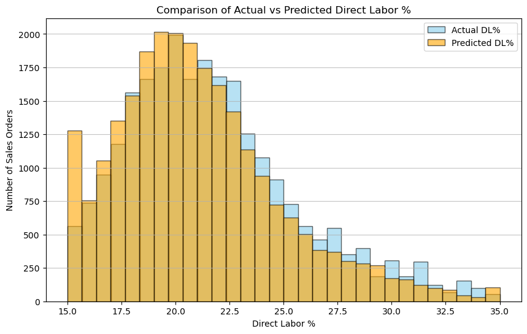

```python
plt.figure(figsize=(10,6))
plt.hist(df['Direct Labor %'], bins=30, alpha=0.6, label='Actual DL%', color='skyblue', edgecolor='black')
plt.hist(df['Predicted DL%'], bins=30, alpha=0.6, label='Predicted DL%', color='orange', edgecolor='black')
plt.title("Comparison of Actual vs Predicted Direct Labor %")
plt.xlabel("Direct Labor %")
plt.ylabel("Number of Sales Orders")
plt.legend()
plt.grid(axis='y', alpha=0.75)
plt.show()
```

```python
df.sample(5)
```

|  | Date | Sales Order Number | Service Type | Service Revenue | Mover Hours | Driver Hours | Labor Cost | Total Revenue | Commission | Direct Labor % | Day of Week | YearMonth | Predicted Labor Cost | Predicted DL% |
| --- | --- | --- | --- | --- | --- | --- | --- | --- | --- | --- | --- | --- | --- | --- |
| 4117 | 2024-01-26 | 0336-69645 | Special Fees | 0.0 | 4.50 | 4.50 | 153.00 | 803.75 | 0.0 | 19.035770 | Friday | 2024-01 | 166.50 | 19.036077 |
| 26675 | 2024-11-16 | 0336-73194 | Cancellation Fee | 0.0 | 3.75 | 3.75 | 131.25 | 747.25 | 0.0 | 17.564403 | Saturday | 2024-11 | 138.75 | 19.071417 |
| 12874 | 2024-01-26 | 0336-69660 | Sales Items | 0.0 | 7.50 | 3.75 | 195.00 | 823.75 | 0.0 | 23.672231 | Friday | 2024-01 | 202.50 | 23.580164 |
| 13701 | 2024-08-07 | 0336-72159 | Sales Items | 0.0 | 4.50 | 9.00 | 252.00 | 828.00 | 0.0 | 30.434783 | Wednesday | 2024-08 | 256.50 | 32.884055 |
| 4244 | 2024-05-02 | 0336-70761 | Special Fees | 0.0 | 4.00 | 2.00 | 114.00 | 633.75 | 0.0 | 17.988166 | Thursday | 2024-05 | 108.00 | 15.517602 |

```python
df.to_excel("dl_rev_data.xlsx", index=False)
```